# Part II - Ford Go Bike Trip

## by Olumide Ogunyemi

## Investigation Overview

In this investigation, I want to look at the type of people who make use of the bike services and determine the possible reason they make use of the bike, either for work or leisure. The main features of interest are user_type, member_birth_year, and member_gender.

## Dataset Overview

The dataset initially contained 183412 samples and 16 features but was reduced to 174952 samples and 16 features after cleaning the data. The dataset consists of features such as duration of ride per sec, start_station, end_station, and end_station_latitude among others but my explanation will revolve around features such as user_type, member_birth_year, member_gender and duration_sec.

## Distribution of Member Gender by Birth Year

There are three types of member gender in the dataset which are Male, Female and Other. Other is assumed to stand for users who are non-binary or whose gender was not disclosed.

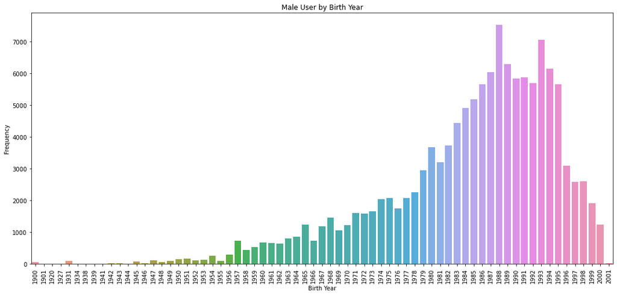

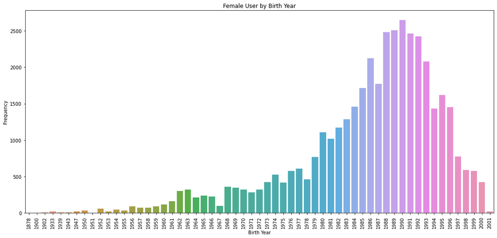

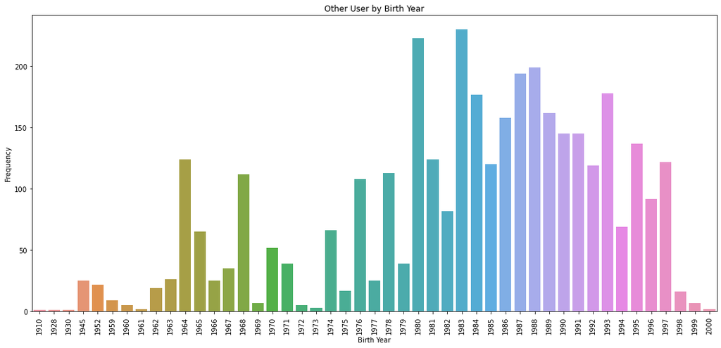

## Member Gender vs Number of User who use bike for all trips.

Although most users are subscribers, the bike is not their main means of transportation. Given that the majority of the users are adults and youths as seen in the previous visualizations, one may conclude that it serves as a means of exercise and leisure.

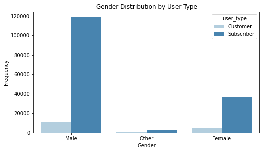

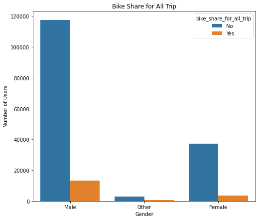

## Distribution of Subscribers and Customers Birth Year, Gender, and Duration of Ride

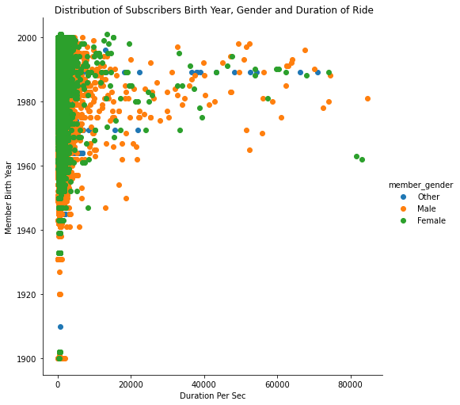

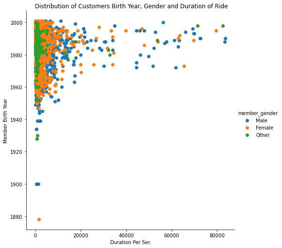